# Smelt recapture analysis - clean version

Rosie

2024-07-12

## Questions we can ask about Delta Smelt realeases

- What influences how far they travel from release site?
  - Release type (Hard, soft)
  - Turbidity
  - First flush
  - Brood Year
- What influences how close together the fish are when they are recaptured?
  - Release type (Hard, soft)
  - Turbidity
  - First Flush
  - Brood Year
- What influences how many fish are recaptured?
  - Release type (Hard, soft)
  - Turbidity
  - First Flush
  - Brood Year

### Data

We have tw0 years of release data (brood years 2022, and 2023) where we have release-specific markings that we can use for this analysis. Most were released at Rio VIsta, but a few were released in the Ship Channel durign the first year. Releases in 2021 did not have release-specific markings, so we can’t really use that to analyze release types.

|  | ReleaseEvent | ReleaseDate | Site | Type | TotalReleased | BroodYear | recapsN | RecapRate | FFyn | WeeklyAve_Turbidity |
| --- | --- | --- | --- | --- | --- | --- | --- | --- | --- | --- |
| 1 | BY2022 1a | 2022-11-29T00:00:00Z | Rio Vista | Soft (carboy) | 6584 | 2022 | 0 | 0 | Before First Flush | 10.10681952781112 |
| 2 | BY2022 1b | 2022-11-30T00:00:00Z | Rio Vista | Hard (carboy) | 6556 | 2022 | 3 | 0.0004575960951799878 | Before First Flush | 9.605762223533482 |
| 3 | BY2022 2a | 2023-01-18T00:00:00Z | Rio Vista | Hard (carboy) | 14524 | 2022 | 13 | 0.0008950702285871661 | After First Flush | 168.5264285714286 |
| 4 | BY2022 2b | 2023-01-18T00:00:00Z | Rio Vista | Hard (trailer) | 3046 | 2022 | 3 | 0.000984898227183191 | After First Flush | 168.5264285714286 |
| 5 | BY2022 3a | 2023-01-25T00:00:00Z | SDWSC | Hard (carboy) | 6755 | 2022 | 13 | 0.001924500370096225 | After First Flush | 129.7396785714286 |
| 6 | BY2022 3b | 2023-01-26T00:00:00Z | SDWSC | Soft (carboy) | 6240 | 2022 | 11 | 0.001762820512820513 | After First Flush | 116.4106428571429 |
| 7 | BY2023 LS1 | 2023-11-15T00:00:00Z | Rio Vista | Hard (large scale) | 14104 | 2023 | 1 | 7.090187180941577e-05 | Before First Flush | 3.688027828080385 |
| 8 | BY2023 1a | 2023-12-12T00:00:00Z | Rio Vista | Hard (carboy) | 6508 | 2023 | 1 | 0.0001536570374923171 | Before First Flush | 4.733749917318644 |
| 9 | BY2023 1b | 2023-12-14T00:00:00Z | Rio Vista | Soft (carboy) | 6581 | 2023 | 3 | 0.000455857772375019 | Before First Flush | 5.112496856094154 |
| 10 | BY2023 2a | 2023-12-19T00:00:00Z | Rio Vista | Hard (carboy) | 6430 | 2023 | 0 | 0 | Before First Flush | 4.849892857142857 |

[output cut: 6 more lines]

## Distance traveled

For the first question, distance traveled from release site, let’s start with a few exploratory plots.

Is distance from release site explained by release type or brood year?

2021 looks a bit closer than the other two years. Soft might be closer than hard, but difficult to tell.

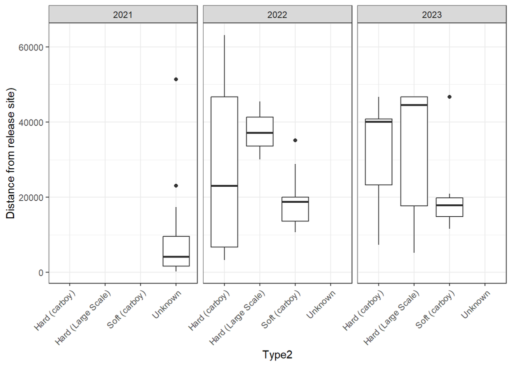

```r
ggplot(filter(recaps3, Type != "Wild/unmarked"), aes(x = Type2, y = Distance)) + geom_boxplot()+
  facet_wrap(~BroodYear)+ ylab("Distance from release site)")+
  theme_bw()+
  theme(axis.text.x = element_text(angle = 45, hjust =1, vjust =1))
```

OK, now let’s test it statistically.

We want to account for the fact that some of these were in paried releases, and the fact that brood years might be different. But our primary goal is hard versus soft.

I’m going to start with the two differen ttypes of hard realeases, then pool all hard releases. I’ll aslo take out 2021 since we can’t trace that one.

Wait - do I need a random effect of release event? I think I do. Maybe that’s my random effect instead of pari? Or does pair cover it?

```r
recaps3.1 = filter(recaps3,  Type != "Wild/unmarked", Type != "Unknown") %>%
  mutate(Pair = str_sub(ReleaseEvent, 1,8), BroodYear = as.factor(BroodYear))

recapmod = lmer(Distance ~ Type2 + BroodYear + (1|Pair), data = recaps3.1)
summary(recapmod)
```

```
## Linear mixed model fit by REML. t-tests use Satterthwaite's method [
## lmerModLmerTest]
## Formula: Distance ~ Type2 + BroodYear + (1 | Pair)
##    Data: recaps3.1
##
## REML criterion at convergence: 1941
##
## Scaled residuals:
##     Min      1Q  Median      3Q     Max
## -1.9178 -0.8145  0.0534  0.8439  2.7363
##
## Random effects:
##  Groups   Name        Variance  Std.Dev.
##  Pair     (Intercept)  33287471  5770
##  Residual             236411866 15376
## Number of obs: 91, groups:  Pair, 7
##
## Fixed effects:
##                          Estimate Std. Error        df t value Pr(>|t|)
## (Intercept)             27950.668   4484.164     5.087   6.233  0.00146 **
## Type2Hard (Large Scale)  2716.540   5929.051    24.253   0.458  0.65091
## Type2Soft (carboy)      -5187.735   4345.340    86.854  -1.194  0.23578
## BroodYear2023            1989.328   6330.902     5.843   0.314  0.76427
## ---
## Signif. codes:  0 '***' 0.001 '**' 0.01 '*' 0.05 '.' 0.1 ' ' 1
##
## Correlation of Fixed Effects:
##             (Intr) T2H(LS Ty2S()
## Typ2H(LScl) -0.162
## Typ2S(crby) -0.227  0.334
## BroodYr2023 -0.588 -0.413 -0.194
```

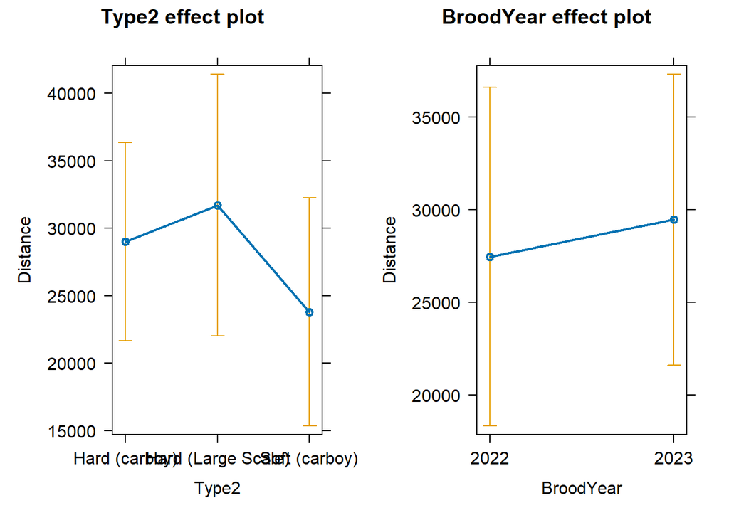

```r
  plot(allEffects(recapmod))
```

No significant differences what so ever.

Let’s try taking out brood year.

```r
recapmod2 = lmer(Distance ~ Type2 + (1|Pair), data = recaps3.1)
summary(recapmod2)
```

```
## Linear mixed model fit by REML. t-tests use Satterthwaite's method [
## lmerModLmerTest]
## Formula: Distance ~ Type2 + (1 | Pair)
##    Data: recaps3.1
##
## REML criterion at convergence: 1960.4
##
## Scaled residuals:
##      Min       1Q   Median       3Q      Max
## -1.90396 -0.81650  0.00856  0.85378  2.70532
##
## Random effects:
##  Groups   Name        Variance  Std.Dev.
##  Pair     (Intercept)  26567116  5154
##  Residual             235585248 15349
## Number of obs: 91, groups:  Pair, 7
##
## Fixed effects:
##                         Estimate Std. Error       df t value Pr(>|t|)
## (Intercept)             28689.49    3444.76    10.60   8.328 5.67e-06 ***
## Type2Hard (Large Scale)  3799.37    5195.01    17.30   0.731    0.474
## Type2Soft (carboy)      -5136.97    4233.50    87.03  -1.213    0.228
## ---
## Signif. codes:  0 '***' 0.001 '**' 0.01 '*' 0.05 '.' 0.1 ' ' 1
##
## Correlation of Fixed Effects:
##             (Intr) T2H(LS
## Typ2H(LScl) -0.564
## Typ2S(crby) -0.448  0.293
```

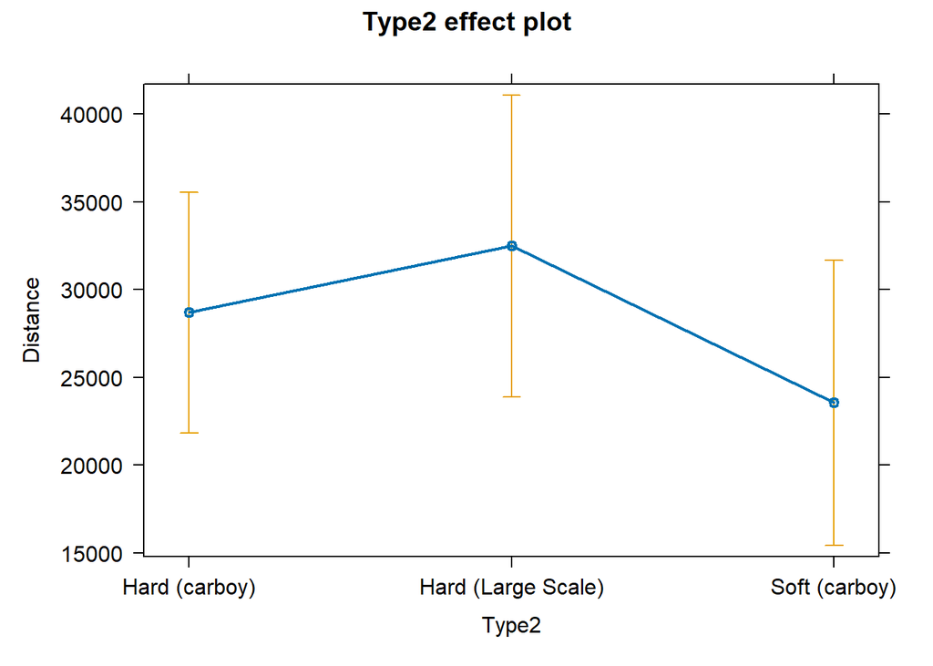

```r
  plot(allEffects(recapmod2))
```

Nope. Now let’s try pooling all the hard realeasees.

```r
recaps3.1 = mutate(recaps3.1, Type3 = case_when(str_detect(Type2, "Hard") ~ "Hard",
                                                str_detect(Type2, "Soft") ~ "Soft"))

recapmod3 = lmer(Distance ~ Type3 + (1|Pair), data = recaps3.1)
summary(recapmod3)
```

```
## Linear mixed model fit by REML. t-tests use Satterthwaite's method [
## lmerModLmerTest]
## Formula: Distance ~ Type3 + (1 | Pair)
##    Data: recaps3.1
##
## REML criterion at convergence: 1979.9
##
## Scaled residuals:
##      Min       1Q   Median       3Q      Max
## -1.98574 -0.81071  0.03644  0.80818  2.69147
##
## Random effects:
##  Groups   Name        Variance  Std.Dev.
##  Pair     (Intercept)  29328027  5416
##  Residual             233417298 15278
## Number of obs: 91, groups:  Pair, 7
##
## Fixed effects:
##             Estimate Std. Error       df t value Pr(>|t|)
## (Intercept) 30088.62    2915.96     7.94  10.319 7.09e-06 ***
## Type3Soft   -5876.22    4045.16    85.09  -1.453     0.15
## ---
## Signif. codes:  0 '***' 0.001 '**' 0.01 '*' 0.05 '.' 0.1 ' ' 1
##
## Correlation of Fixed Effects:
##           (Intr)
## Type3Soft -0.350
```

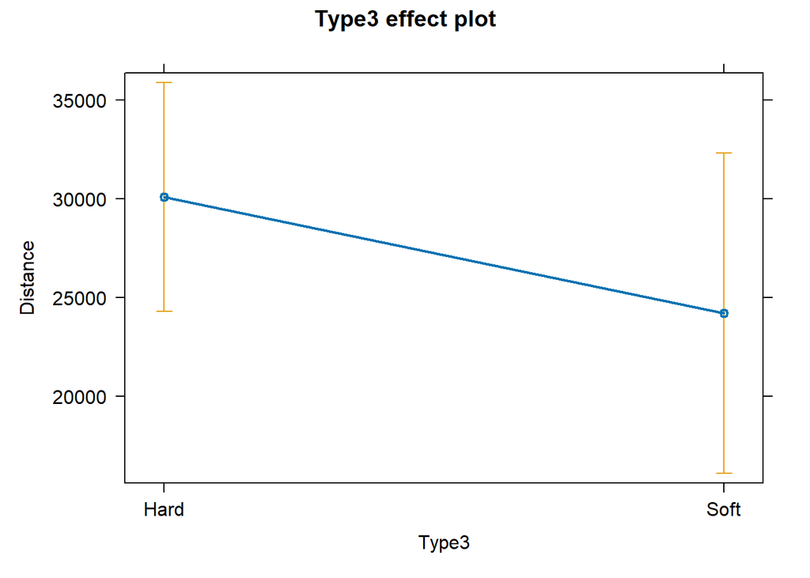

```r
  plot(allEffects(recapmod3))
```

Nope, still not significant.

OK, now what about turbidity?

```r
recaps3.2 = left_join(recaps3.1, turbdat_ave, by = c("ReleaseDate" = "Date"))

recapmod4 = lmer(Distance ~ weekturb + (1|Pair), data = recaps3.2)
summary(recapmod4)
```

```
## Linear mixed model fit by REML. t-tests use Satterthwaite's method [
## lmerModLmerTest]
## Formula: Distance ~ weekturb + (1 | Pair)
##    Data: recaps3.2
##
## REML criterion at convergence: 1990.4
##
## Scaled residuals:
##     Min      1Q  Median      3Q     Max
## -2.0003 -0.8144 -0.1192  0.8246  2.9330
##
## Random effects:
##  Groups   Name        Variance  Std.Dev.
##  Pair     (Intercept)  52180228  7224
##  Residual             232899089 15261
## Number of obs: 91, groups:  Pair, 7
##
## Fixed effects:
##              Estimate Std. Error        df t value Pr(>|t|)
## (Intercept) 29343.567   4761.139     6.972   6.163 0.000469 ***
## weekturb      -10.471     53.797     5.606  -0.195 0.852537
## ---
## Signif. codes:  0 '***' 0.001 '**' 0.01 '*' 0.05 '.' 0.1 ' ' 1
##
## Correlation of Fixed Effects:
##          (Intr)
## weekturb -0.719
```

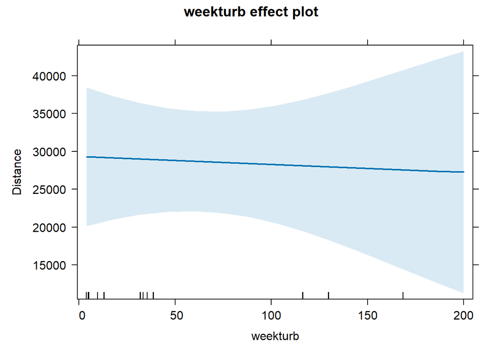

```r
  plot(allEffects(recapmod4))
```

How about before versus after first flush?

```r
recapmod5 = lm(Distance ~ FFyn, data = recaps3.2)
summary(recapmod5)
```

```
##
## Call:
## lm(formula = Distance ~ FFyn, data = recaps3.2)
##
## Residuals:
##    Min     1Q Median     3Q    Max
## -23317 -14161  -4441  14608  36920
##
## Coefficients:
##             Estimate Std. Error t value Pr(>|t|)
## (Intercept)    32137       3307   9.717 1.23e-15 ***
## FFynYes        -5873       3884  -1.512    0.134
## ---
## Signif. codes:  0 '***' 0.001 '**' 0.01 '*' 0.05 '.' 0.1 ' ' 1
##
## Residual standard error: 16540 on 89 degrees of freedom
## Multiple R-squared:  0.02505,    Adjusted R-squared:  0.0141
## F-statistic: 2.287 on 1 and 89 DF,  p-value: 0.134
```

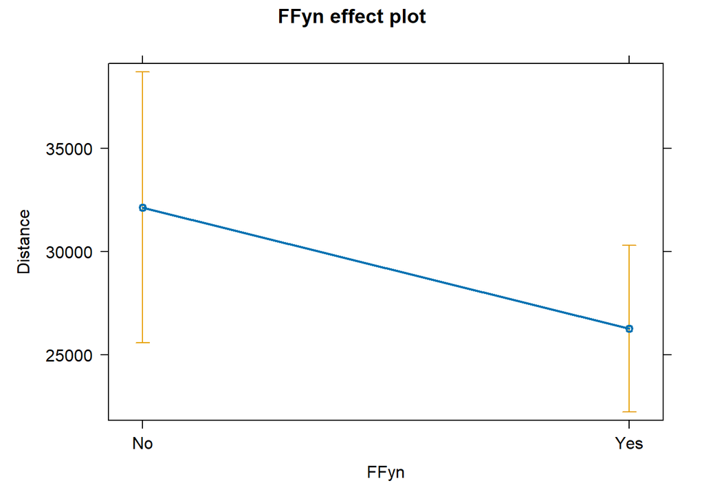

```r
  plot(allEffects(recapmod5))
```

There’s a difference, but it’s not significant.

Just to be thorough, let’s put all the possible predictors in a model and see which AIC says is best.

```r
recapmodGlobal = lmer(Distance ~ FFyn + BroodYear + Type3 + weekturb + (1|Pair), data = recaps3.2,
                      na.action = "na.fail", REML = FALSE)

dredge(recapmodGlobal)
```

```
## Fixed term is "(Intercept)"
```

```
## Global model call: lmer(formula = Distance ~ FFyn + BroodYear + Type3 + weekturb +
##     (1 | Pair), data = recaps3.2, REML = FALSE, na.action = "na.fail")
## ---
## Model selection table
##    (Intrc) BrdYr FFyn Type3   wktrb df    logLik   AICc delta weight
## 1    28630                           3 -1009.014 2024.3  0.00  0.194
## 5    30140                +          4 -1007.934 2024.3  0.03  0.191
## 6    28130     +          +          5 -1007.663 2026.0  1.73  0.082
## 3    30810          +                4 -1008.869 2026.2  1.90  0.075
## 7    32220          +     +          5 -1007.770 2026.2  1.94  0.073
## 2    27080     +                     4 -1008.908 2026.3  1.98  0.072
## 13   31470                + -18.870  5 -1007.826 2026.4  2.05  0.069
## 9    29370                  -11.310  4 -1008.985 2026.4  2.13  0.067
## 8    29840     +    +     +          6 -1007.592 2028.2  3.88  0.028
## 14   25740     +          +  18.520  6 -1007.628 2028.3  3.95  0.027
## 4    29300     +    +                5 -1008.814 2028.3  4.03  0.026
## 11   30730          +         7.829  5 -1008.860 2028.4  4.12  0.025
## 10   25110     +             15.910  5 -1008.886 2028.5  4.17  0.024
## 15   32310          +     +  -6.623  6 -1007.761 2028.5  4.22  0.024
## 16   22430     +    +     +  85.470  7 -1007.236 2029.8  5.52  0.012
## 12   22250     +    +        89.230  6 -1008.476 2030.0  5.65  0.012
## Models ranked by AICc(x)
## Random terms (all models):
##   1 | Pair
```

It says that the null model with no predictors is best, followed closely by just the release type.

Overall, we didn’t see much influence on distance traveled from any of our predictors.

## Distance between recaptures

Now let’s move on to distance between recaptures. Personally, I don’t love this metric, because unless they are caught in the same trawl, we can’t really say they are schooling or derriving any benifit from being close together, but we’ll do it anyway.

Is distance between recaptures explained by release type or brood year?

Exploritoary plots

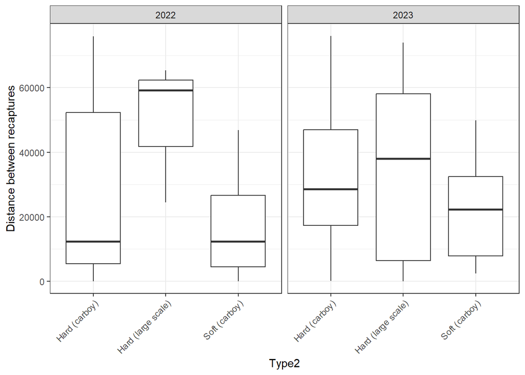

```r
ggplot(filter(alldist2.1), aes(x = Type2, y = Distance)) + geom_boxplot()+
  facet_wrap(~BroodYear)+ ylab("Distance between recaptures")+
  theme_bw()+
  theme(axis.text.x = element_text(angle = 45, hjust =1, vjust =1))
```

It doesn’t look like there was a big difference bwteen brood years, but maybe somthing with release type.

We want to account for the fact that some of these were in paried releases, and the fact that brood years might be different. But our primary goal is hard versus soft.

I’m going to start with the two differen ttypes of hard realeases, then pool all hard releases.

```r
alldist2.1 = mutate(alldist2.1, Pair = str_sub(ReleaseEvent, 1, 8), BroodYear = as.factor(BroodYear))
school1 = lmer(Distance ~ Type2 + BroodYear + (1|Pair), data = alldist2.1)
summary(school1)
```

```
## Linear mixed model fit by REML. t-tests use Satterthwaite's method [
## lmerModLmerTest]
## Formula: Distance ~ Type2 + BroodYear + (1 | Pair)
##    Data: alldist2.1
##
## REML criterion at convergence: 10124.9
##
## Scaled residuals:
##      Min       1Q   Median       3Q      Max
## -1.53742 -0.82672 -0.08049  0.86921  2.14505
##
## Random effects:
##  Groups   Name        Variance  Std.Dev.
##  Pair     (Intercept)   7276682  2698
##  Residual             551100337 23476
## Number of obs: 444, groups:  Pair, 7
##
## Fixed effects:
##                          Estimate Std. Error        df t value Pr(>|t|)
## (Intercept)             27472.566   2579.219     1.968  10.652  0.00919 **
## Type2Hard (large scale)  3970.434   4627.813     3.390   0.858  0.44731
## Type2Soft (carboy)      -9615.604   3249.086   198.841  -2.959  0.00346 **
## BroodYear2023            3903.721   4366.031     2.532   0.894  0.44802
## ---
## Signif. codes:  0 '***' 0.001 '**' 0.01 '*' 0.05 '.' 0.1 ' ' 1
##
## Correlation of Fixed Effects:
##             (Intr) T2H(s) Ty2S()
## Typ2Hr(scl) -0.099
## Typ2S(crby) -0.286  0.251
## BroodYr2023 -0.495 -0.631 -0.104
```

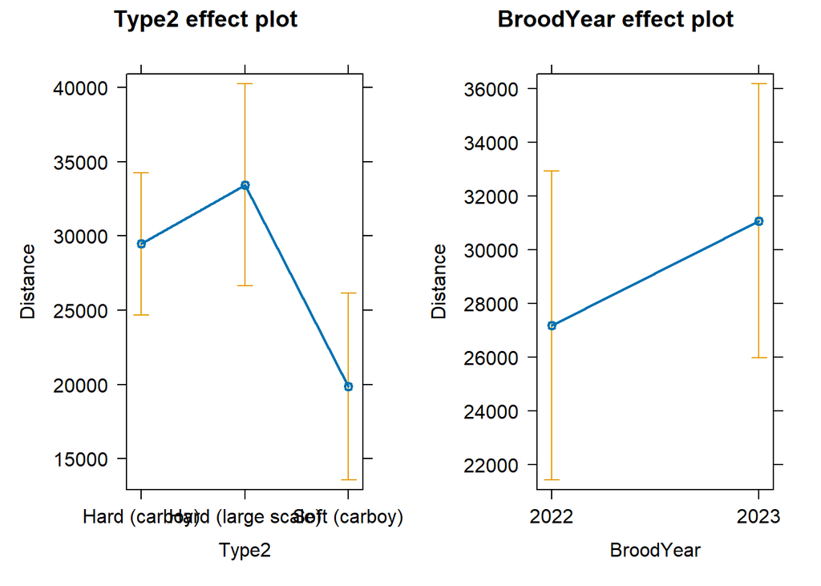

```r
  plot(allEffects(school1))
```

So, soft realeases were closer together than hard releases, no difference between the carboy hard releases and large-scale releases, and no difference between brood years.

OK, now what about turbidity?

```r
#join turbidity and first flush info
FF = select(recaps3.1, ReleaseEvent, FFyn) %>%
  distinct()
alldist3 = left_join(alldist2.1, turbdat_ave, by = c("ReleaseDate" = "Date")) %>%
  left_join(FF)
school2a = lm(Distance ~ weekturb, data = alldist3)
summary(school2a)
```

```
##
## Call:
## lm(formula = Distance ~ weekturb, data = alldist3)
##
## Residuals:
##    Min     1Q Median     3Q    Max
## -33282 -20704  -4107  20199  50087
##
## Coefficients:
##             Estimate Std. Error t value Pr(>|t|)
## (Intercept) 34117.86    1844.56  18.496  < 2e-16 ***
## weekturb      -64.21      18.34  -3.502 0.000509 ***
## ---
## Signif. codes:  0 '***' 0.001 '**' 0.01 '*' 0.05 '.' 0.1 ' ' 1
##
## Residual standard error: 24040 on 442 degrees of freedom
## Multiple R-squared:  0.02699,    Adjusted R-squared:  0.02479
## F-statistic: 12.26 on 1 and 442 DF,  p-value: 0.0005093
```

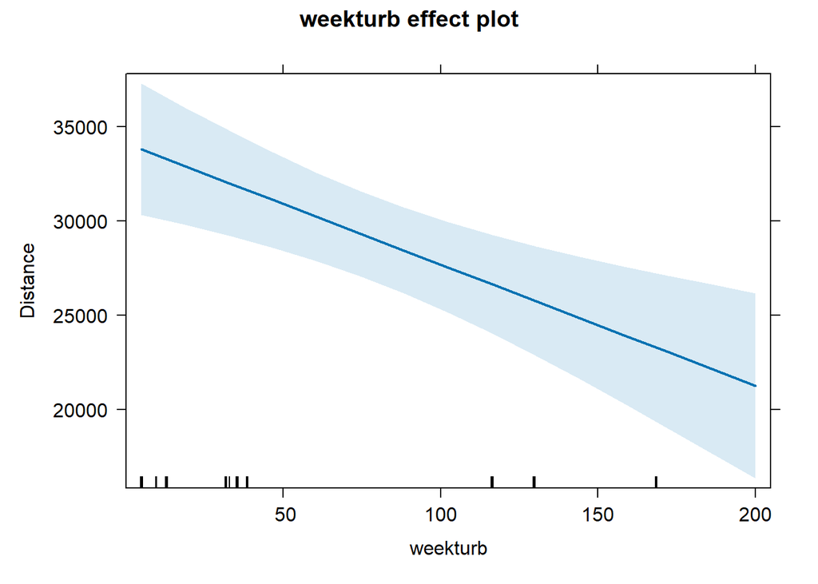

```r
  plot(allEffects(school2a))
```

```r
  school2 = lmer(Distance ~ weekturb + (1|Pair), data = alldist3)
summary(school2)
```

```
## Linear mixed model fit by REML. t-tests use Satterthwaite's method [
## lmerModLmerTest]
## Formula: Distance ~ weekturb + (1 | Pair)
##    Data: alldist3
##
## REML criterion at convergence: 10181.4
##
## Scaled residuals:
##     Min      1Q  Median      3Q     Max
## -1.5202 -0.7920 -0.1399  0.7690  2.3183
##
## Random effects:
##  Groups   Name        Variance  Std.Dev.
##  Pair     (Intercept)  28396518  5329
##  Residual             557849465 23619
## Number of obs: 444, groups:  Pair, 7
##
## Fixed effects:
##              Estimate Std. Error        df t value Pr(>|t|)
## (Intercept) 32245.066   4049.309     5.025   7.963 0.000492 ***
## weekturb      -38.645     41.950     4.144  -0.921 0.407379
## ---
## Signif. codes:  0 '***' 0.001 '**' 0.01 '*' 0.05 '.' 0.1 ' ' 1
##
## Correlation of Fixed Effects:
##          (Intr)
## weekturb -0.761
```

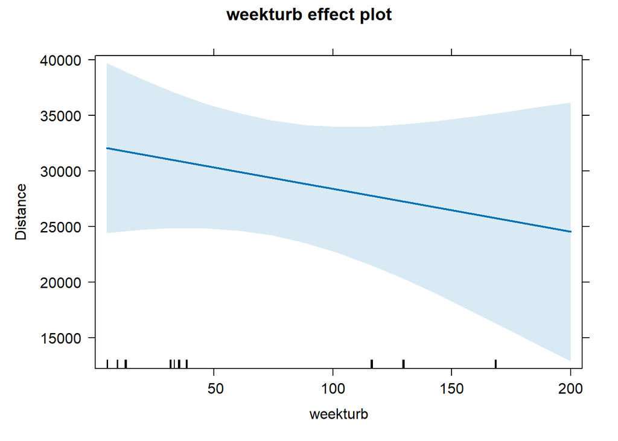

```r
  plot(allEffects(school2))
```

No significant difference when I include the random effect of pair. I think i have to because smelt from a particular release event are not independent replicates.

I’m going to skip the first flush model and jump right to dredging the global model

```r
schoolmodGlobal = lmer(Distance ~ FFyn + BroodYear + Type2 + weekturb + (1|Pair), data = alldist3,
                      na.action = "na.fail", REML = FALSE)
```

```
## boundary (singular) fit: see help('isSingular')
```

```r
dredge(schoolmodGlobal)
```

```
## Fixed term is "(Intercept)"
## boundary (singular) fit: see help('isSingular')
## boundary (singular) fit: see help('isSingular')
## boundary (singular) fit: see help('isSingular')
## boundary (singular) fit: see help('isSingular')
## boundary (singular) fit: see help('isSingular')
## boundary (singular) fit: see help('isSingular')
```

```
## Global model call: lmer(formula = Distance ~ FFyn + BroodYear + Type2 + weekturb +
##     (1 | Pair), data = alldist3, REML = FALSE, na.action = "na.fail")
## ---
## Model selection table
##    (Intrc) BrdYr FFyn Type2   wktrb df    logLik    AICc delta weight
## 6    27070     +          +          6 -5097.285 10206.8  0.00  0.186
## 5    28370                +          5 -5098.370 10206.9  0.12  0.176
## 7    34190          +     +          6 -5097.579 10207.3  0.59  0.139
## 13   32500                + -35.570  6 -5097.636 10207.5  0.70  0.131
## 8    32420     +    +     +          7 -5096.609 10207.5  0.71  0.130
## 15   36070          +     + -27.390  7 -5097.171 10208.6  1.84  0.074
## 14   25250     +          +  12.530  7 -5097.265 10208.8  2.02  0.068
## 16   25770     +    +     +  60.560  8 -5096.240 10208.8  2.05  0.067
## 12   15220     +    +       150.000  6 -5100.233 10212.7  5.90  0.010
## 3    36120          +                4 -5102.748 10213.6  6.82  0.006
## 4    32700     +    +                5 -5102.345 10214.8  8.07  0.003
## 1    29380                           3 -5104.544 10215.1  8.38  0.003
## 2    25790     +                     4 -5103.733 10215.6  8.80  0.002
## 11   36230          +        -8.191  5 -5102.724 10215.6  8.82  0.002
## 9    32620                  -43.880  4 -5103.920 10215.9  9.17  0.002
## 10   25620     +              1.239  5 -5103.733 10217.6 10.84  0.001
## Models ranked by AICc(x)
## Random terms (all models):
##   1 | Pair
```

I don’t think I”d want turbidity and first flush in the same model, so we’d have to choose. Neither are significant, so maybe just don’t use either of them. Brood year didn’t come out as significant, so I’m tempted to leave that out too.

```r
bestschool = lmer(Distance ~  Type2 + (1|Pair), data = alldist3)

summary(bestschool)
```

```
## Linear mixed model fit by REML. t-tests use Satterthwaite's method [
## lmerModLmerTest]
## Formula: Distance ~ Type2 + (1 | Pair)
##    Data: alldist3
##
## REML criterion at convergence: 10144.3
##
## Scaled residuals:
##      Min       1Q   Median       3Q      Max
## -1.53774 -0.78921 -0.07243  0.92341  2.14163
##
## Random effects:
##  Groups   Name        Variance  Std.Dev.
##  Pair     (Intercept)   9055782  3009
##  Residual             550381625 23460
## Number of obs: 444, groups:  Pair, 7
##
## Fixed effects:
##                          Estimate Std. Error        df t value Pr(>|t|)
## (Intercept)             28678.450   2356.521     4.487  12.170 0.000132 ***
## Type2Hard (large scale)  6433.090   3783.270     4.212   1.700 0.160665
## Type2Soft (carboy)      -9213.223   3243.328   287.982  -2.841 0.004823 **
## ---
## Signif. codes:  0 '***' 0.001 '**' 0.01 '*' 0.05 '.' 0.1 ' ' 1
##
## Correlation of Fixed Effects:
##             (Intr) T2H(s)
## Typ2Hr(scl) -0.605
## Typ2S(crby) -0.373  0.228
```

This leaves us with the conclusion that soft release fish stayed closer together.

## Number of recaptures

The percentage of fish recaptured gives us some idea whether there are differences in survival rates between the release types, which I think is one of hte more interesting things.

Is percentage of fish recaptured explained by release type or brood year?

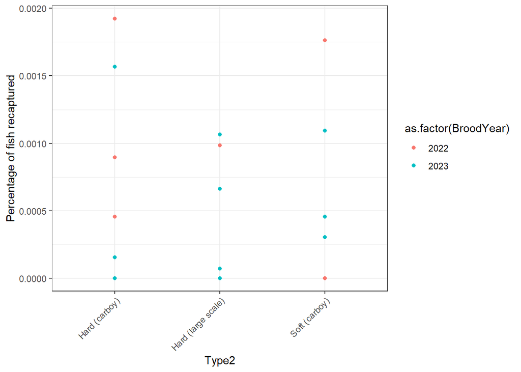

```r
ggplot(releasestat, aes(x = Type2, y = RecapRate, color = as.factor(BroodYear))) +
  geom_point()+ ylab("Percentage of fish recaptured")+
  theme_bw()+
  theme(axis.text.x = element_text(angle = 45, hjust =1, vjust =1))
```

There aren’t a lot of data, it’s pretty hard to tell anything.

```r
releasestat = mutate(releasestat, BroodYear = as.factor(BroodYear),
                     Type3 = case_when(str_detect(Type2, "Hard") ~ "Hard",
                                       str_detect(Type2, "Soft") ~ "Soft"))
rates1 = lm(RecapRate ~ Type2 + BroodYear, data = releasestat)
summary(rates1)
```

```
##
## Call:
## lm(formula = RecapRate ~ Type2 + BroodYear, data = releasestat)
##
## Residuals:
##        Min         1Q     Median         3Q        Max
## -0.0009844 -0.0004637 -0.0001245  0.0005575  0.0009515
##
## Coefficients:
##                           Estimate Std. Error t value Pr(>|t|)
## (Intercept)              1.050e-03  3.260e-04   3.223  0.00732 **
## Type2Hard (large scale) -1.458e-04  4.185e-04  -0.349  0.73350
## Type2Soft (carboy)      -6.605e-05  4.061e-04  -0.163  0.87350
## BroodYear2023           -4.350e-04  3.571e-04  -1.218  0.24652
## ---
## Signif. codes:  0 '***' 0.001 '**' 0.01 '*' 0.05 '.' 0.1 ' ' 1
##
## Residual standard error: 0.000668 on 12 degrees of freedom
## Multiple R-squared:   0.14,  Adjusted R-squared:  -0.07504
## F-statistic: 0.651 on 3 and 12 DF,  p-value: 0.5974
```

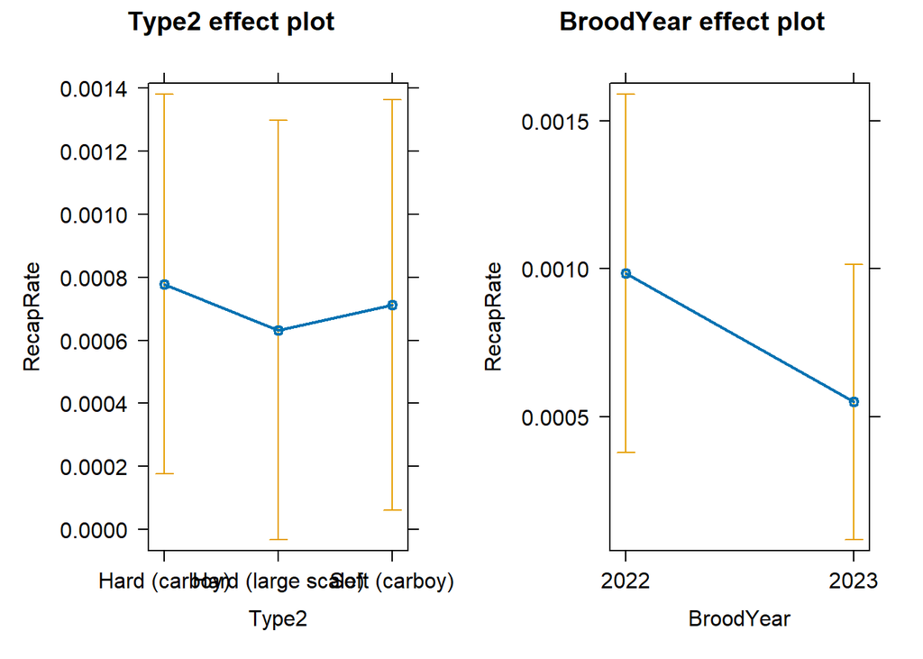

```r
  plot(allEffects(rates1))
```

Meh.

```r
rates2 = lm(RecapRate ~ Type3, data = releasestat)
summary(rates2)
```

```
##
## Call:
## lm(formula = RecapRate ~ Type3, data = releasestat)
##
## Residuals:
##        Min         1Q     Median         3Q        Max
## -0.0007234 -0.0005744 -0.0001471  0.0003606  0.0012171
##
## Coefficients:
##              Estimate Std. Error t value Pr(>|t|)
## (Intercept) 7.074e-04  2.011e-04   3.518  0.00341 **
## Type3Soft   1.606e-05  3.597e-04   0.045  0.96502
## ---
## Signif. codes:  0 '***' 0.001 '**' 0.01 '*' 0.05 '.' 0.1 ' ' 1
##
## Residual standard error: 0.0006669 on 14 degrees of freedom
## Multiple R-squared:  0.0001424,  Adjusted R-squared:  -0.07128
## F-statistic: 0.001993 on 1 and 14 DF,  p-value: 0.965
```

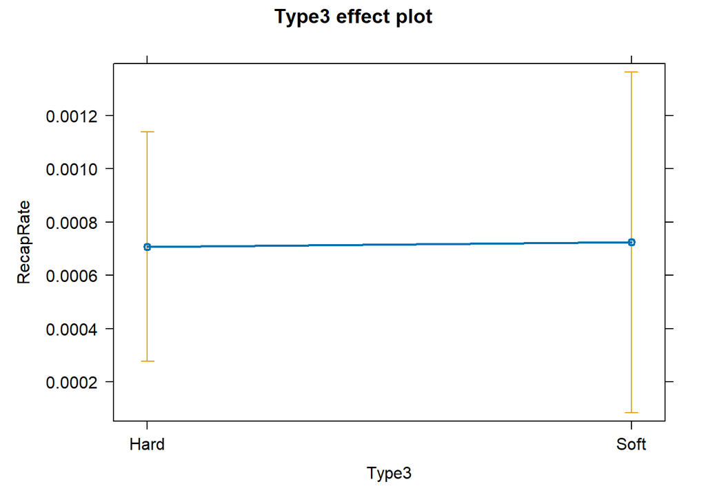

```r
  plot(allEffects(rates2))
```

Nope. You definitely don’t get more recaptures by release type.

OK, now what about turbidity?

```r
rates3 = lm(RecapRate ~ weekturb, data = releasestat)
summary(rates3)
```

```
##
## Call:
## lm(formula = RecapRate ~ weekturb, data = releasestat)
##
## Residuals:
##        Min         1Q     Median         3Q        Max
## -0.0006406 -0.0004116 -0.0001219  0.0004551  0.0009453
##
## Coefficients:
##              Estimate Std. Error t value Pr(>|t|)
## (Intercept) 3.783e-04  1.660e-04   2.278  0.03891 *
## weekturb    6.868e-06  2.183e-06   3.146  0.00715 **
## ---
## Signif. codes:  0 '***' 0.001 '**' 0.01 '*' 0.05 '.' 0.1 ' ' 1
##
## Residual standard error: 0.0005105 on 14 degrees of freedom
## Multiple R-squared:  0.4141, Adjusted R-squared:  0.3723
## F-statistic: 9.895 on 1 and 14 DF,  p-value: 0.007153
```

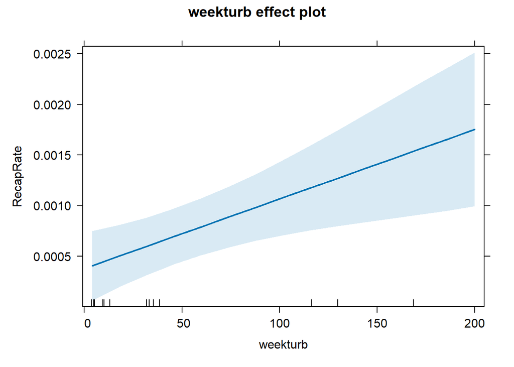

```r
  plot(allEffects(rates3))
```

So you do get a significant impact of nuber of recaptures based on turbiidty the week after release!

```r
ratesglobal = lm(RecapRate ~ FFyn + BroodYear + Type3 + weekturb , data = releasestat,
                      na.action = "na.fail")

dredge(ratesglobal)
```

```
## Fixed term is "(Intercept)"
```

```
## Global model call: lm(formula = RecapRate ~ FFyn + BroodYear + Type3 + weekturb,
##     data = releasestat, na.action = "na.fail")
## ---
## Model selection table
##      (Intrc) BrdYr FFyn Type3      wktrb df  logLik   AICc delta weight
## 3  0.0012000          +                   3 102.906 -197.8  0.00  0.534
## 4  0.0013110     +    +                   4 103.494 -195.4  2.46  0.156
## 11 0.0010290          +        1.885e-06  4 103.227 -194.8  2.99  0.119
## 7  0.0012480          +     +             4 103.090 -194.5  3.27  0.104
## 8  0.0013590     +    +     +             5 103.693 -191.4  6.43  0.021
## 9  0.0003783                   6.868e-06  3  99.648 -191.3  6.52  0.021
## 12 0.0013080     +    +        1.837e-08  5 103.494 -191.0  6.82  0.018
## 15 0.0010870          +     +  1.616e-06  5 103.313 -190.6  7.19  0.015
## 10 0.0002027     +             7.976e-06  4  99.814 -188.0  9.82  0.004
## 13 0.0003448                +  6.938e-06  4  99.718 -187.8 10.01  0.004
## 16 0.0014910     +    +     + -1.007e-06  6 103.730 -186.1 11.68  0.002
## 1  0.0007124                              2  95.371 -185.8 11.99  0.001
## 2  0.0010040     +                        3  96.497 -185.0 12.82  0.001
## 14 0.0001425     +          +  8.182e-06  5  99.920 -183.8 13.97  0.000
## 5  0.0007073                +             3  95.372 -182.7 15.07  0.000
## 6  0.0010040     +          +             4  96.497 -181.4 16.45  0.000
## Models ranked by AICc(x)
```

So, the best model by AIC is with first flush, but the weekly turbidity and brood year are also within a delta AIC of 3, so could be included.

Again, I wouldn’t want the first flush and weeekly turbidity in the same model, so we’d want to choose our favorite.

Brood year isn’t significant, and doesn’t improve the model, so I’ll leave that off.

```r
ratesbest = lm(RecapRate ~ weekturb , data = releasestat)
summary(ratesbest)
```

```
##
## Call:
## lm(formula = RecapRate ~ weekturb, data = releasestat)
##
## Residuals:
##        Min         1Q     Median         3Q        Max
## -0.0006406 -0.0004116 -0.0001219  0.0004551  0.0009453
##
## Coefficients:
##              Estimate Std. Error t value Pr(>|t|)
## (Intercept) 3.783e-04  1.660e-04   2.278  0.03891 *
## weekturb    6.868e-06  2.183e-06   3.146  0.00715 **
## ---
## Signif. codes:  0 '***' 0.001 '**' 0.01 '*' 0.05 '.' 0.1 ' ' 1
##
## Residual standard error: 0.0005105 on 14 degrees of freedom
## Multiple R-squared:  0.4141, Adjusted R-squared:  0.3723
## F-statistic: 9.895 on 1 and 14 DF,  p-value: 0.007153
```

```r
ratesbest2 = lm(RecapRate ~ FFyn , data = releasestat)
summary(ratesbest2)
```

```
##
## Call:
## lm(formula = RecapRate ~ FFyn, data = releasestat)
##
## Residuals:
##        Min         1Q     Median         3Q        Max
## -0.0008957 -0.0002251 -0.0001202  0.0002662  0.0007249
##
## Coefficients:
##                          Estimate Std. Error t value Pr(>|t|)
## (Intercept)             0.0011996  0.0001472   8.148 1.11e-06 ***
## FFynBefore First Flush -0.0009745  0.0002082  -4.680 0.000354 ***
## ---
## Signif. codes:  0 '***' 0.001 '**' 0.01 '*' 0.05 '.' 0.1 ' ' 1
##
## Residual standard error: 0.0004164 on 14 degrees of freedom
## Multiple R-squared:  0.6101, Adjusted R-squared:  0.5822
## F-statistic: 21.91 on 1 and 14 DF,  p-value: 0.0003541
```

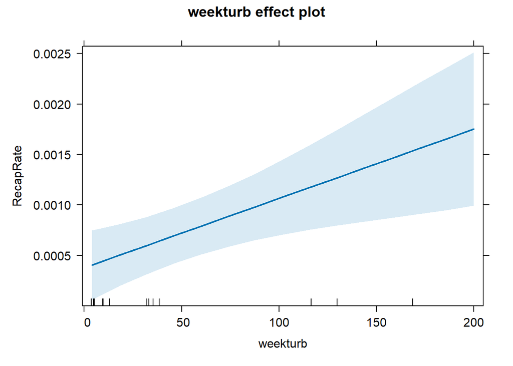

```r
plot(allEffects(ratesbest))
```

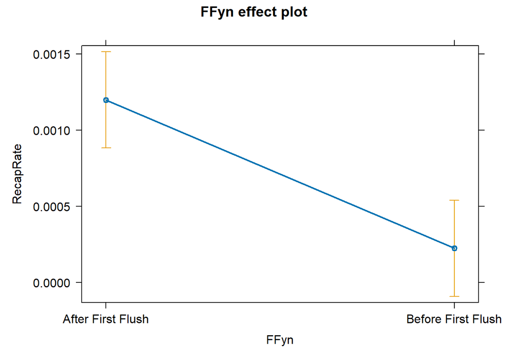

```r
plot(allEffects(ratesbest2))
```